# A World of Difference: How Food System Emissions Are Distributed Globally

Author

Rachel Spellenberg

Published

February 24, 2024

For this infographic, I was interested in three questions:

1. What countries have the highest total food system emissions?
2. What countries have the highest per capita food system emissions?
3. Is there a relationship between total Land Use and Land Use Change (LULUC) and per capita consumption emissions?

I used two datasets to answer the above questions:

1. I accessed the EDGAR-FOOD data set from the March 24, 2021 edition of Data is Plural linked on the assignment page. I used the country name, year (1990-2018), food system stage, and emissions in kt of CO2 equivalent for the infographic.
2. I accessed population data from the World Bank to be able to calculate per capita emissions. This data set included population and year (1990-2018) for the five countries I was highlighting in my infographic.

To answer the first question, I decided to make a world map where I could color the top five emitting countries in a color I could use throughout the whole infographic. This served as helpful context for the viewer to visualize the locations I was focusing on and a way to keep color consistent throughout the page. For the second question, I went with a bar graph because it was the most straightforward way to present the information. I did try a few more advanced chart types, but it was clearer to leave as a bar chart. To answer the third question, I created two radar plots because it was a great way to see the difference between LULUC and consumption while also being a visually appealing chart. I limited as much text as I could on my charts because I knew I was going to be adding annotations to my infographic. Because I was keeping color consistent throughout, I knew I could get rid of legends. For themes, I tried to remove as much as I could that was not necessary to understanding the information on the infographic. For colors and typography, I kept it consistent throughout the infographic. I chose colors that were easy to tell apart and checked them with the “Let’s Get Colorblind” extension on Google Chrome. I chose “Nunito” font since it had good readability on the page. To avoid information overload, I ended up deleting a couple plots that I originally intended to include. I realized it was more important to have enough space to have my plots big enough, while also leaving some blank space. I tried to have each question answered as a section of the infographic so the viewers eye naturally moves through it rather than jumping around. All the questions I was exploring in this infographic were very related, so it was simplest to center my primary message in the title and subtitle of the infographic. As for DEI, I tried to call attention to the fact that the countries that have emissions from LULUC are exporting those goods, while the countries with the highest per capita consumption emissions are importing those goods. I can’t definitively say the cause, but I think it is important to highlight because if you only look at total emissions it is easy to miss some of the nuance.

With all this being said, I didn’t have a clear idea on how my infographic would come together until I started arranging my exploratory plots in a Google slide to test the layout. Once I was looking at things next to each other I found a clearer direction in what plots I should include and where.

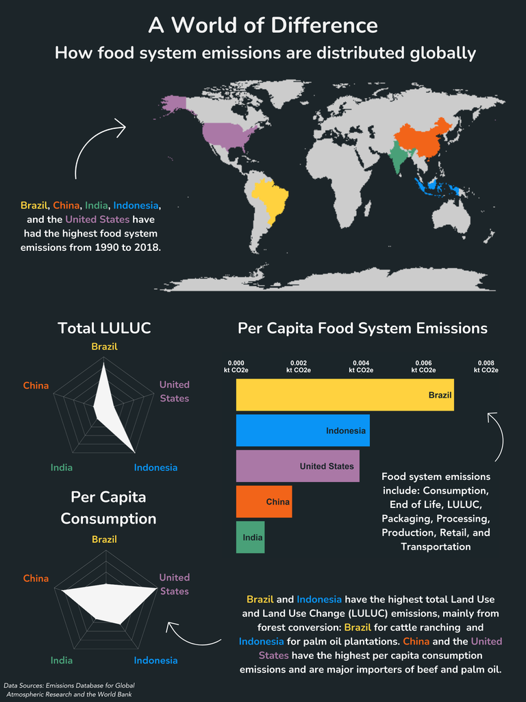

```r
  # include png of my infographic to render in html
  knitr::include_graphics("pictures/RSpellenberg_infographic_hw4.png")
```

### Packages and Data

```r
# loading packages ----
library(tidyverse)
library(janitor)
library(here)
library(maps)
library(fmsb)
library(ggtext)
library(showtext)

# read in data ----
food_emissions_raw <- read_csv(here("data/EDGAR-FOOD_v6_GHG FOOD system emi.csv"))

population_raw <- read_csv(here("data/population-data-worldbank.csv"))

food_sector_emissions_raw <- read_csv(here("data/EDGAR-FOOD_v6_FOOD emi by sector .csv"), skip = 3)
```

### Data Wrangling

```r
# data wrangling ----------

# tidying up EDGAR dataset for food emissions by country 1990-2018 ----

food_emissions <- food_emissions_raw %>%

  # snake case column headers
  clean_names() %>%

  # tidy up!
  pivot_longer(cols = 3:31,
               names_to = "year",
               values_to = "emissions_kt_co2e") %>%

  # removing country code variable
  select(-country_code_a3) %>%

  # rename first first column
  rename(country = name) %>%

  # remove y_ from each observation and change class to numeric
  mutate(year = as.numeric(str_remove_all(year, "y_"))) %>%

  # round the values in the emissions_kt_co2e column
  mutate(emissions_kt_co2e = round(emissions_kt_co2e, 2)) %>%

  # filtering for 5 top emitters (by total emissions)
  filter(country == "China" | country == "Brazil" | country == "United States" | country == "India" | country == "Indonesia") %>%

  # add in data for the rest of the world's population and emissions in 2018
  add_row(country = "rest of the world", year = 2018, emissions_kt_co2e = 9270996) %>%

  # factor the countries and 'rest of the world' for coloring in plots
   mutate(country = factor(country, levels = c("China", "Brazil", "United States", "India", "Indonesia", "rest of the world")))


# tidying population dataset from World Bank to use for per capita calculations ----

population <- population_raw %>%

  # snake case column headers
  clean_names() %>%

  # selecting desired columns
  select(country_name, 5:29) %>%

  # rename column name to 'country'
  rename(country = country_name) %>%

  # tidy up!
  pivot_longer(cols = 2:26,
               names_to = "year",
               values_to = "population") %>%

  # clean up year variable to be YYYY format and change to numeric
  mutate(year = as.numeric(substr(year, 9, 12))) %>%

  # add observation to include population of the rest of the world beyond the 5 countries highlighted in the infographic
 add_row(country = "rest of the world", year = 2018, population = 4107954888)


  # creating df for plots that include per capita data ------------

  # joining population and food system data into one df
  per_capita_emissions <- merge(food_emissions, population, by = c("country", "year"), all.x = TRUE) %>%

  # adding per capita emissions
  mutate(per_capita_emissions = emissions_kt_co2e/population)


# tidying EDGAR food emissions by sector data for radar plots ----------

food_sector_emi <- food_sector_emissions_raw %>%

  # snake case column headers
  clean_names() %>%

  # selecting desired columns
  select(name, dev_country, food_system_stage, 7:35) %>%

  # renaming 'name' to 'country'
  rename(country = name) %>%

  # tidy up!
  pivot_longer(cols = 4:32,
               names_to = "year",
               values_to = "emissions") %>%

  # remove y_ from each observation and change class to numeric
  mutate(year = as.numeric(str_remove_all(year, "y_"))) %>%

  # converting emissions to numeric class
  mutate(emissions = as.numeric(emissions)) %>%

  # only using data for 2018
  filter(year == 2018) %>%

  # filtering for top 5 countries
  filter(country == "China" |
         country == "Brazil" |
         country == "United States" |
         country == "India" |
         country == "Indonesia")  %>%

  # renaming food system stages
  mutate(food_system_stage = case_when(
      food_system_stage == "Consumption" ~ "CONS",
      food_system_stage == "End_of_Life" ~ "EOL",
      food_system_stage == "LULUC (Production)" ~ "LULUC",
      food_system_stage == "Packaging" ~ "PACK",
      food_system_stage == "Processing" ~ "PROC",
      food_system_stage == "Production" ~ "PROD",
      food_system_stage == "Retail" ~ "RET",
      food_system_stage == "Transport" ~ "TRAN")) %>%

  # grouping data by country and food system stage
  group_by(country, food_system_stage) %>%

  # summing emissions of grouped observations
  summarize(total_emissions = sum(emissions))

  # creating df for 2018 population ---
  pop_2018 <- population %>%

    # filtering for 2018
    filter(year == 2018) %>%

    # excluding "rest of the world"
    filter(country != "rest of the world")


  # creating df that combines food sector emissions and population for 2018 ---
  food_emi_2018_pc <- full_join(food_sector_emi, pop_2018) %>%

    # grouping data by country, food system stage, and popluation
    group_by(country, food_system_stage, population) %>%

    # summing emissions based on grouped observations
    summarize(total_emissions = sum(total_emissions)) %>%

    # create new column that calculates per capita emissions
    mutate(per_cap_emi = total_emissions/population)


# --------------------dfs for radar plots --------------------


# df for consumption radar plot ----------

  # consumption radar plot ---
  radar_pc_pop <- population %>%

    # filtering for 2018
    filter(year == 2018) %>%

    # removing "rest of the world"
    filter(country != "rest of the world")

  # creating df that only includes consumption emissions data ---
  food_sector_emi_pc <- food_sector_emi %>%

    # filtering for only consumption
    filter(food_system_stage == "CONS")

  # joining above dfs to combine food section emissions and population
  cons_pc_emissions <- full_join(food_sector_emi_pc, radar_pc_pop) %>%

    # calculating per capita consumption emissions
    mutate(pc_emissions = total_emissions/population)

  # df for consumption radar plot (wider data) -----
  cons_radar <- cons_pc_emissions %>%

    # keeping two columns: country and per capita emissions
    select(country, pc_emissions) %>%

    # wider data format for radar plot
    pivot_wider(names_from = country,
                values_from = pc_emissions)

  # adding in 0.00015 for max in radarplot -----
  br_cons_max <- data.frame(country = "Brazil", pc_emissions = 0.00015)
  ch_cons_max <- data.frame(country = "China", pc_emissions = 0.00015)
  india_cons_max <- data.frame(country = "India", pc_emissions = 0.00015)
  ind_cons_max <- data.frame(country = "Indonesia", pc_emissions = 0.00015)
  us_cons_max <- data.frame(country = "United States", pc_emissions = 0.00015)

  # joining above dfs into one for maximum radar plot values
  cons_radar_max <- rbind(br_cons_max, ch_cons_max, india_cons_max, ind_cons_max, us_cons_max) %>%

    # wider data format for radar plot
    pivot_wider(names_from = country,
                values_from = pc_emissions)

  # adding in 0 for min in radarplot -----
  br_cons_min <- data.frame(country = "Brazil", pc_emissions = 0)
  ch_cons_min <- data.frame(country = "China", pc_emissions = 0)
  india_cons_min <- data.frame(country = "India", pc_emissions = 0)
  ind_cons_min <- data.frame(country = "Indonesia", pc_emissions = 0)
  us_cons_min <- data.frame(country = "United States", pc_emissions = 0)

  # joining above dfs into one for minimum radar plot values
  cons_radar_min <- rbind(br_cons_min, ch_cons_min, india_cons_min, ind_cons_min, us_cons_min) %>%

    # wider data format for radar plot
    pivot_wider(names_from = country,
                values_from = pc_emissions)

  # put it all together ------
  cons_radar_final <- rbind(cons_radar_max, cons_radar_min, cons_radar) %>%

    # adding spaces to headers to adjust spacing on radar plot
    rename("             United States" = "United States",
           "China  " = "China")


# df for LULUC radar plot ----------

  # df for LULUC radar plot (wider data) -----

 luluc_radar <- food_sector_emi %>%

    # filtering to only include LULUC emissions
    filter(food_system_stage == "LULUC") %>%

    # keeping two columns: country and total_emissions
    select(country, total_emissions) %>%

    # wider data format for radar plots
    pivot_wider(names_from = country,
                values_from = total_emissions) %>%

    # add observation to include LULUC for United States
    mutate("United States" = 0)

  # adding in 772000 for max in radarplot -----
  br_luluc_max <- data.frame(country = "Brazil", total_emissions = 772000)
  ch_luluc_max <- data.frame(country = "China", total_emissions = 772000)
  india_luluc_max <- data.frame(country = "India", total_emissions = 772000)
  ind_luluc_max <- data.frame(country = "Indonesia", total_emissions = 772000)
  us_luluc_max <- data.frame(country = "United States", total_emissions = 772000)

  # joining above dfs into one for maximum radar plot values
  luluc_radar_max <- rbind(br_luluc_max, ch_luluc_max, india_luluc_max, ind_luluc_max, us_luluc_max) %>%

    # wider data format for radat plot
    pivot_wider(names_from = country,
                values_from = total_emissions)

  # adding in 0 for min in radarplot -----
  br_luluc_min <- data.frame(country = "Brazil", total_emissions = 0)
  ch_luluc_min <- data.frame(country = "China", total_emissions = 0)
  india_luluc_min <- data.frame(country = "India", total_emissions = 0)
  ind_luluc_min <- data.frame(country = "Indonesia", total_emissions = 0)
  us_luluc_min <- data.frame(country = "United States", total_emissions = 0)

  # joining above dfs into one for minimum radar plot values
  luluc_radar_min <- rbind(br_luluc_min, ch_luluc_min, india_luluc_min, ind_luluc_min, us_luluc_min) %>%

    # wider data format for radat plot
    pivot_wider(names_from = country,
                values_from = total_emissions)

 # put it all together ------
  luluc_radar_final <- rbind(luluc_radar_max, luluc_radar_min, luluc_radar) %>%

  # adding spaces to headers to djust spacing on radar plot
    rename("             United States" = "United States",
           "China  " = "China")
```

### Plots

```r
# creating theme for all plots ------
  my_pal1 <- c("China" = "#F26419",
            "Brazil" = "#FFD23F",
            "United States" = "#AA78A6",
            "India" = "#49A078",
            "Indonesia" = "#0a94f5")

  my_pal2 <- c("China" = "#F26419",
            "Brazil" = "#FFD23F",
            "United States" = "#AA78A6",
            "India" = "#49A078",
            "Indonesia" = "#0a94f5",
            "rest of the world" = "#CCCCCC")

# font for plots -----
  font <- font_add_google(name = "Nunito", family = "nunito")

# ---------- bar chart for per capita emissions in 2018 -------------

# start of saving as png
png(file = "pictures/bar.png", units = "in", width = 15, height = 12, res=300, bg = 'transparent')

  per_capita_plot <- per_capita_emissions %>%

  # only using 2018 data
  filter(year == 2018) %>%

  # removing "rest of the world" from bar chart
  filter(country != "rest of the world") %>%

  ggplot() +

  # building bar chart
  geom_col(aes(x = reorder(country, per_capita_emissions), y = per_capita_emissions), fill = my_pal1) +

  # adding country names as labels within the bar chart
  geom_text(aes(x = country, y = per_capita_emissions, label = country), hjust = 1.1, size = 11.5, fontface = "bold", family = "nunito", color = "#1B2529") +

  # moving y-axis to the right so that it ends up on top once flipped. Adding "kt CO2e" after each x-axis label so that I can remove axis title in infographic
  scale_y_continuous(position = "right", labels = scales::label_number(accuracy = 0.002, scale = 1, suffix = "\nkt CO2e"), limits = c(0, 0.008)) +

  coord_flip() +

  # adding title
  labs(title = "Per Capita Food System Emissions") +

  # adjusting look of plot ---
  theme(plot.title = element_text(face = "bold", family = "nunito",
                                  size = 30, color = "white",
                                  hjust = 0.5, margin = margin(0, 50, 50, 50)),
        plot.margin = margin(t = 10, r = 10, b = 10, l = 10),
        panel.background = element_rect(fill = "#1B2529"),
        plot.background = element_rect(fill = "#1B2529"),
        panel.grid = element_line(linetype = "blank"),
        axis.title = element_blank(),
        axis.text.y = element_blank(),
        axis.ticks.y = element_blank(),
        axis.ticks.x = element_line(color = "white"),
        axis.text.x = element_text(face = "bold",
                              family = "nunito",
                              size = 25,
                              color = "white"))


  per_capita_plot

  # end of saving as png
  dev.off()

# ---------- radar plots -------------


# per capita consumption radar plot ------

  # saving as png start
  png(file = "pictures/consumption_radar.png", units = "in", width = 15, height = 12, res=300, bg = 'transparent')

  # building radar chart (for pasting into infographic to have more control over labels and fonts)
  radarchart(cons_radar_final, pcol = "gray95", pfcol = scales::alpha("gray95", 0.75), plwd = 2, plty = 1,

           # customize the grid
           cglcol = "white", cglty = 1, cglwd = 0.8,

           # customize the axes
           axislabcol = "white",

           #variable labels
           vlcex = 2, vlabels = NULL, caxislabels = NULL, title = NULL)

  # saving as png end
  dev.off()


# total LULUC radar plot ------

  # saving as png start
  png(file = "pictures/luluc_radar.png", units = "in", width = 15, height = 12, res=300, bg = 'transparent')

  # building radar chart (for pasting into infographic to have more control over labels and fonts)
  radarchart(luluc_radar_final, pcol = "gray95", pfcol = scales::alpha("gray95", 0.75), plwd = 2, plty = 1,

           # customize the grid
           cglcol = "white", cglty = 1, cglwd = 0.8,

           # customize the axes
           axislabcol = "white",

           #variable labels
           vlcex = 2, vlabels = NULL, caxislabels = NULL, title = NULL)

  # saving as png end
  dev.off()


  # ----------- map for center of infographic -----------
  # code for building map in ggplot from Sarah Penir; edited to fit aesthetic for infographic

  # creating df for map -----
  world <- map_data("world") %>%

    # removing subregion column
    select(-subregion) %>%

    # creating new column for the countries I want to highlight on my map
    mutate(map = case_when(
      region == "China" ~ "China",
      region == "Brazil" ~ "Brazil",
      region == "USA" ~ "United States",
      region == "India" ~ "India",
      region == "Indonesia" ~ "Indonesia"))

  # creating df for all countries I'm NOT highlighting in my map
  world_filtered_rotw <- world %>%

    filter(region != "China") %>%
    filter(region != "Brazil") %>%
    filter(region != "USA") %>%
    filter(region != "India") %>%
    filter(region != "Indonesia") %>%

    # populating column with "rest of the world" to be able to match gray to the rest of my infographic
    mutate(map = "rest of the world")

  # creating df with the 5 countries I'm highlighting in my map/infographic
  world_filtered_top5 <- world %>%

    filter(map == "China" |
           map == "Brazil" |
           map == "United States" |
           map == "India" |
           map == "Indonesia")

  # joining together 2 dfs so that map column has been fully populated with the 6 categories I have colors for
  world_final <- full_join(world_filtered_top5, world_filtered_rotw)

  # map viz ---

  # saving as png start
  png(file = "pictures/map.png",  bg = 'transparent')

  map <- ggplot() +

    geom_polygon(data = world_final, aes(x=long, y = lat, group = group, fill = map)) +

    scale_fill_manual(values = my_pal2) +

    coord_fixed(1.3) +

    #get rid of axes and background
    theme_void() +

    # changing bacground color to match infographic
    theme(legend.position = "none",
          panel.background = element_rect(fill = "#1B2529"),
          plot.background = element_rect(fill = "#1B2529"))

  map

  # saving as png end
  dev.off()
```

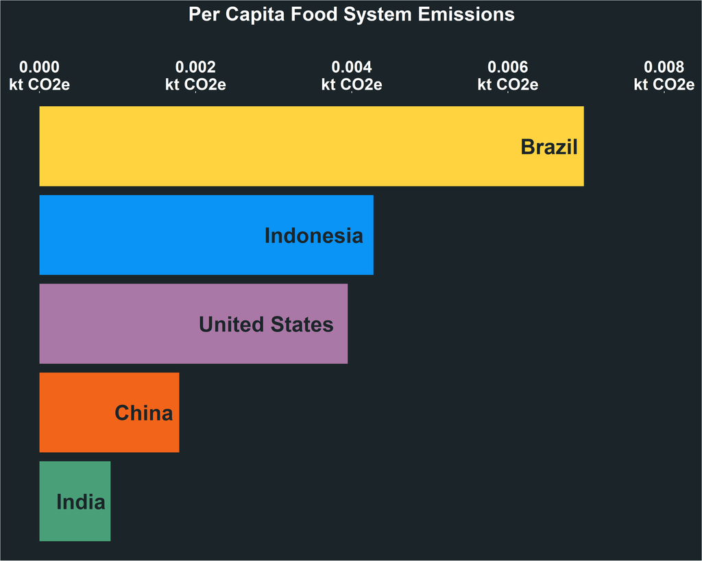

```r
# code chunk to render plots in html ------

 # including to render bar chart in html
  knitr::include_graphics("pictures/bar.png")
```

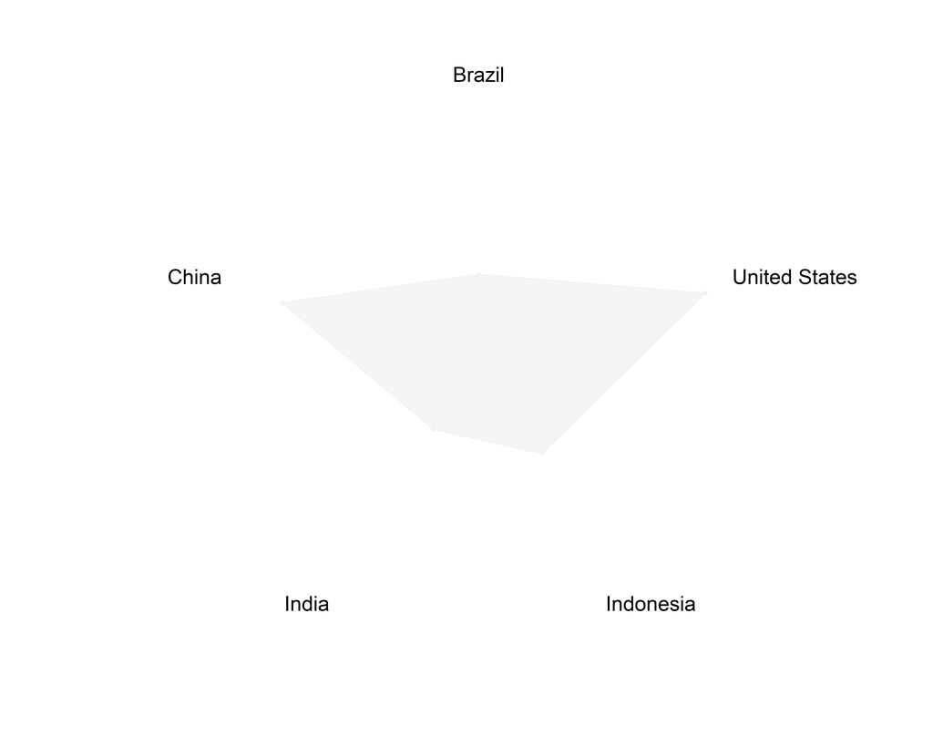

```r
  # including to render radar chart in html
  knitr::include_graphics("pictures/consumption_radar.png")
```

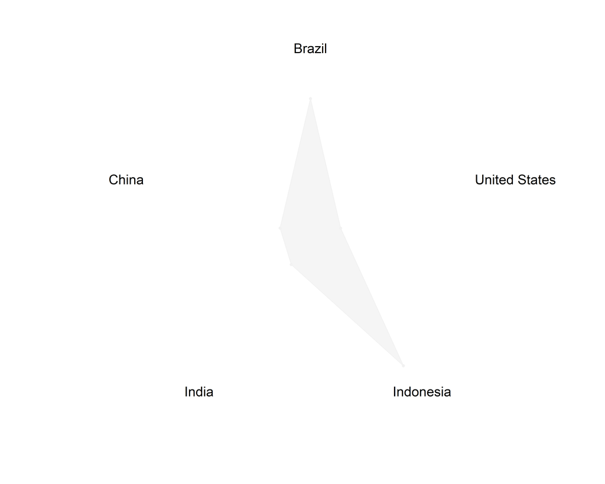

```r
  # including to render radar chart in html
  knitr::include_graphics("pictures/luluc_radar.png")
```

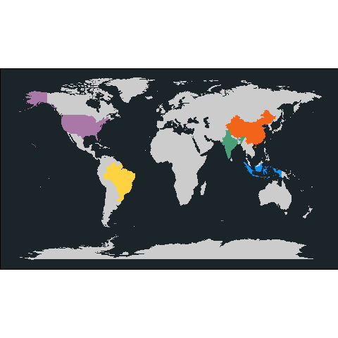

```r
  # including to render map in html
  knitr::include_graphics("pictures/map.png")
```